# PCA

```python
%matplotlib inline
import numpy as np
from numpy.linalg import eig
import matplotlib.pyplot as plt
import matplotlib.image as mpimg
```

## Image Compression via PCA

This file gives a simple example on how to use PCA for image compression. A grey image is a $m\times n$ matrix, which can be considered as a set of samples $\{\mathbf x^{(1)}, \ldots, \mathbf x^{(m)}\}, \mathbf x^{(i)} \in \mathbb R^n.$ We can use PCA to do dimension reduction on the dataset to compress the image.

Let us implement the PCA algorithm firstly. The main steps of PCA involves:

1. Standardize the dataset
2. Compute covariance matrix
3. Find principal components through eigen decomposition
4. project data on the components

We can define a `standardize` function to standardize a dataset:

```python
def standardize(samples):
    # standardize samples
    mean = np.mean(samples, axis=0)
    var = np.mean((samples - mean)**2, axis=0)
    std_samples = (samples - mean) / np.sqrt(var)
    return mean, var, std_samples
```

Now, define a `PCA` function to compute the components and projections.

```python
def PCA(std_samples):
    # compute covariance
    cov = std_samples.T @ std_samples / std_samples.shape[0]
    e_val, e_vec = eig(cov)
    idx = np.flip(np.argsort(np.real(e_val)))
    components = np.real(e_vec[:,idx])
    return std_samples @ components, components
```

With the components and projections, we can define a `recover` function to recover the original dataset with mean values and variances. Note that you can choose how many components you want to use.

```python
def recover(projections, components, mean, var):
    recovered_samples = projections @ (components.T)
    recovered_samples = recovered_samples * np.sqrt(var) + mean
    return recovered_samples
```

Now we can perform image compression with PCA. The original image is shown as follows:

[figure not shown]

The original size is $(900 \times 900 \times 3)$. Now, standardize the dataset and compute the components and projections. *Note that we have a RGB image here, so we need to apply PCA on three color channels respectively.*

```python
im = mpimg.imread('./dog.jpg')
im_mat = np.array(im)
# get data from three color channels respectively
im_r = im_mat[:, :, 0]
im_g = im_mat[:, :, 1]
im_b = im_mat[:, :, 2]
mean_r, var_r, std_samples_r = standardize(im_r)
mean_g, var_g, std_samples_g = standardize(im_g)
mean_b, var_b, std_samples_b = standardize(im_b)
projections_r, components_r =  PCA(std_samples_r)
projections_g, components_g =  PCA(std_samples_g)
projections_b, components_b =  PCA(std_samples_b)
```

Finally, use `recover` function to recover the image with $k$ components. We will set $k = {1, 5, 25, 125}$ to see the differences.

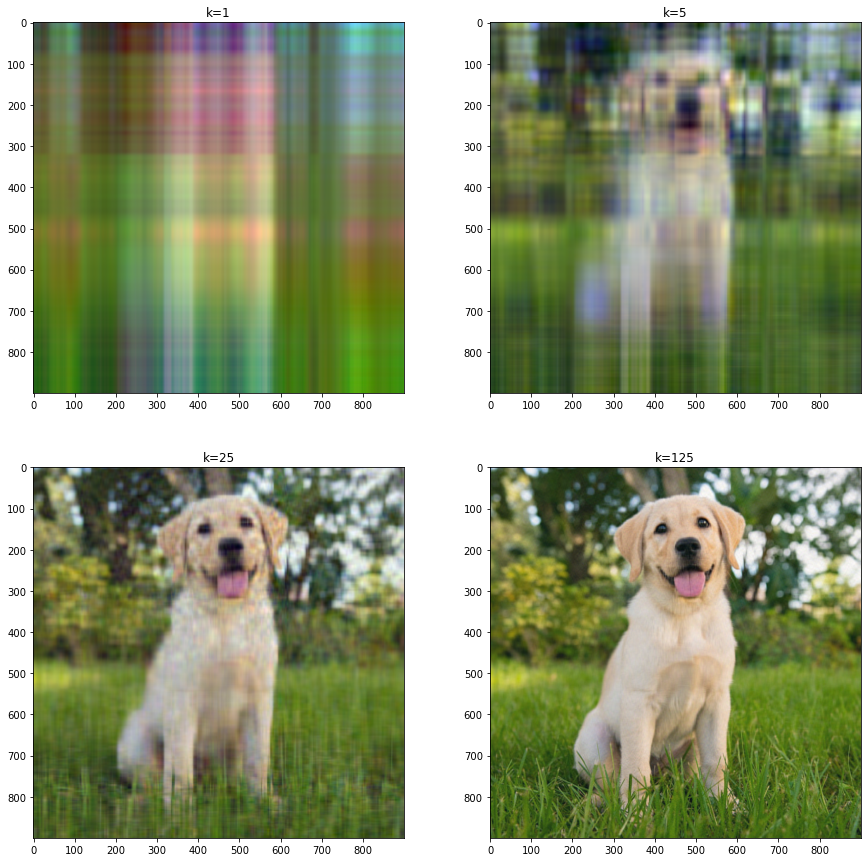

```python
i=1
# make sure the value is bounded in [0, 255]
def bound(im):
    if np.min(im) < 0:
        im = im - np.min(im)
    if np.max(im) > 255:
        im = im / np.max(im) * 255
    return im
plt.figure(figsize=(15, 15))
for k in [1, 5, 25, 125]:
    recovered_im_r = bound(recover(projections_r[:, 0:k], components_r[:, 0:k], mean_r, var_r))
    recovered_im_g = bound(recover(projections_g[:, 0:k], components_g[:, 0:k], mean_g, var_g))
    recovered_im_b = bound(recover(projections_b[:, 0:k], components_b[:, 0:k], mean_b, var_b))

    im_mat[:, :, 0] = recovered_im_r
    im_mat[:, :, 1] = recovered_im_g
    im_mat[:, :, 2] = recovered_im_b
    plt.subplot(2, 2, i)
    plt.title("k={}".format(k))
    plt.imshow(im_mat)
    i+=1
plt.show()
```

With $k=125$, we can actually get a quiet good result. Of couse, image compression is a popular topic in computer vision. There are more advanced methods. Here, we just show how to use PCA for image compression. Hopefully it can give you some insights.